# STAT2 : STATISTIQUE DESCRIPTIVE

### Boîte à moustaches

La fonction `boxplot()` permet de visualiser une distribution sous forme de boîte à moustache où l’on repère facilement :

La syntaxe de base est la suivante :

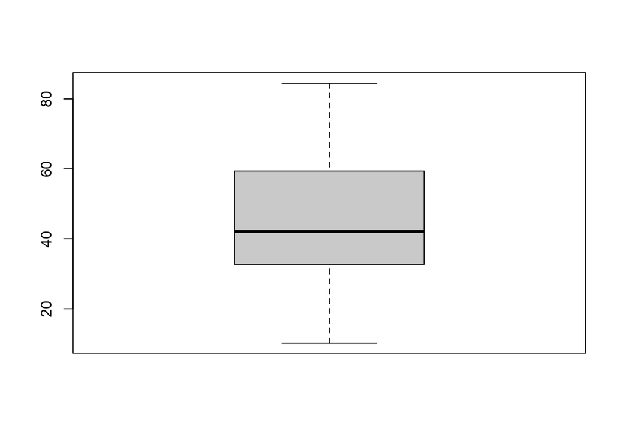

```r
X<-don$MORINF
boxplot(X)
```

Mais on peut améliorer la figure avec quelques paramètres de plus

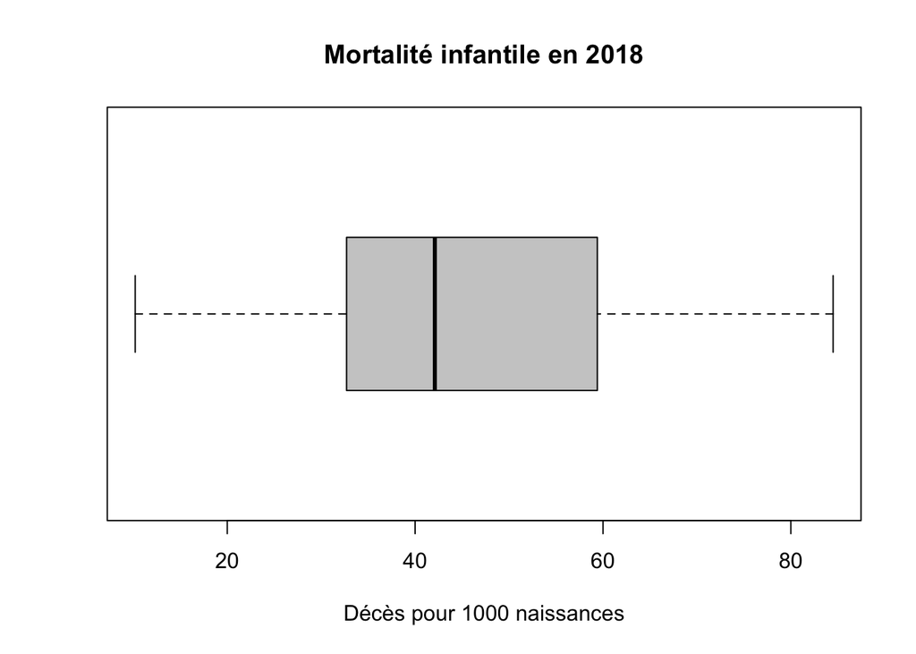

```r
boxplot(X,horizontal = TRUE, col = "gray80",
        main = "Mortalité infantile en 2018",
        xlab = "Décès pour 1000 naissances")
```

### Histogramme

Comme d’habitude, on peut appliquer la syntaxe la plus simple :

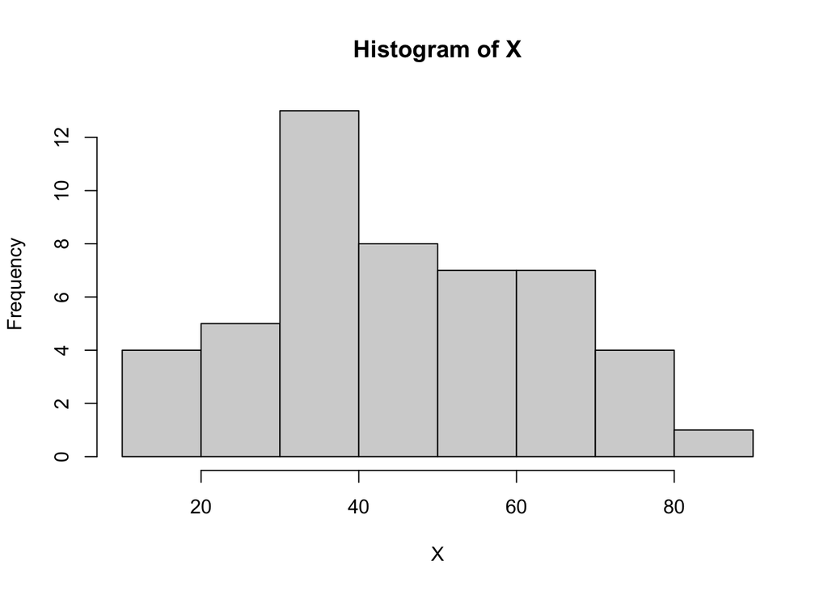

```r
X<-don$MORINF
hist(X)
```

On peut ensuite améliorer avec l’ajout de titres et un choix précis de classes. On remarque que si les classes sont d’amplitudes inégales R utilise la densité de probabilité (rapport entre effectif et amplitude de la classe) et non plus l’effectif ce qui est statistiquement correct (et que ne fait pas Excel …).

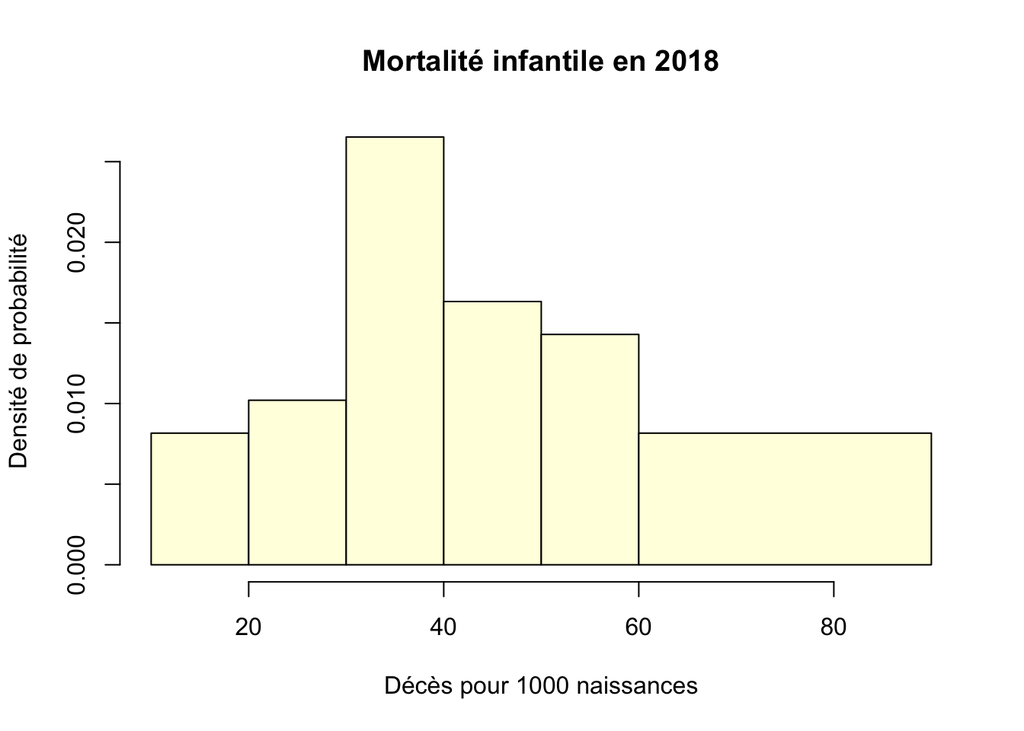

```r
hist(X,
     breaks = c(10, 20, 30,40,50, 60,90),
     col= "lightyellow",
     main = "Mortalité infantile en 2018",
     ylab = "Densité de probabilité",
     xlab = "Décès pour 1000 naissances")
```

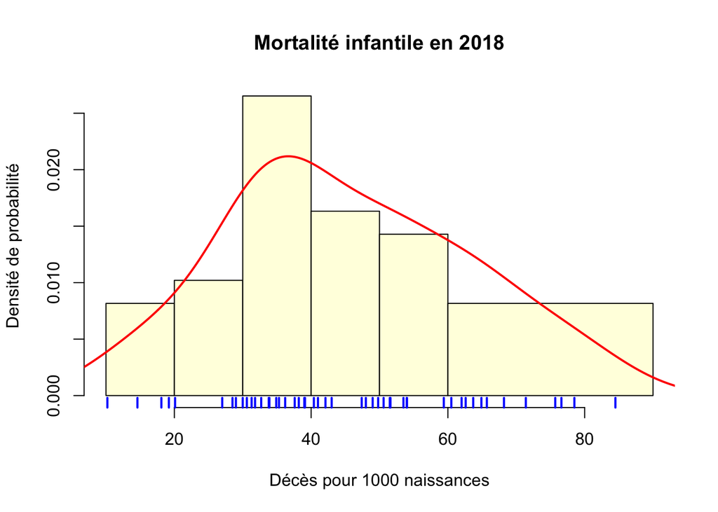

```r
hist(X,
     breaks = c(10, 20, 30,40,50, 60,90),
     col= "lightyellow",
     main = "Mortalité infantile en 2018",
     ylab = "Densité de probabilité",
     xlab = "Décès pour 1000 naissances")
lines(density(X),col="red",lwd=2)
rug(X, col="blue",lwd=2)
```

## Exploration III (*2 variables*)

Nous verrons en détail dans les chapitres suivants comment croiser deux variables d’un point de vue statistiques. Mais on peut déjà indiquer brièvement comment les visualiser rapidement à l’aide de trois exemples.

### Deux variables qualitatives

- Tableau de contingence

```r
X <- as.factor(don$LANGFR)
levels(X)<-c("non francophone", "francophone")
Y<-cut(don$POP, breaks=c(0,10,20,200))
levels(Y) <- c("petit","moyen","grand")
tab<-table(X,Y)
addmargins(tab)
```

```
                 Y
X                 petit moyen grand Sum
  non francophone    11     5    11  27
  francophone         6     9     7  22
  Sum                17    14    18  49
```

- Graphique

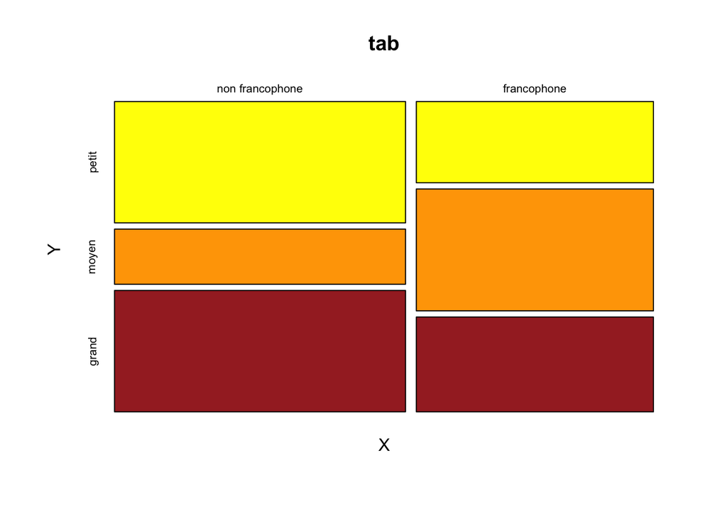

```r
plot(tab, col=c("yellow","orange","brown"))
```

- Test (Chi-2)

```r
test<-chisq.test(X,Y)
test
```

```
    Pearson's Chi-squared test

data:  X and Y
X-squared = 3.0236, df = 2, p-value = 0.2205
```

### Deux variables quantitatives

- Paramètres principaux

```r
Y <- don$MORINF
X<-don$PIB
summary(X)
```

```
   Min. 1st Qu.  Median    Mean 3rd Qu.    Max.    NA's
    757    2015    3290    5169    6437   19459       3
```

```r
summary(Y)
```

```
   Min. 1st Qu.  Median    Mean 3rd Qu.    Max.
  10.20   32.70   42.10   45.32   59.40   84.50
```

- Graphique

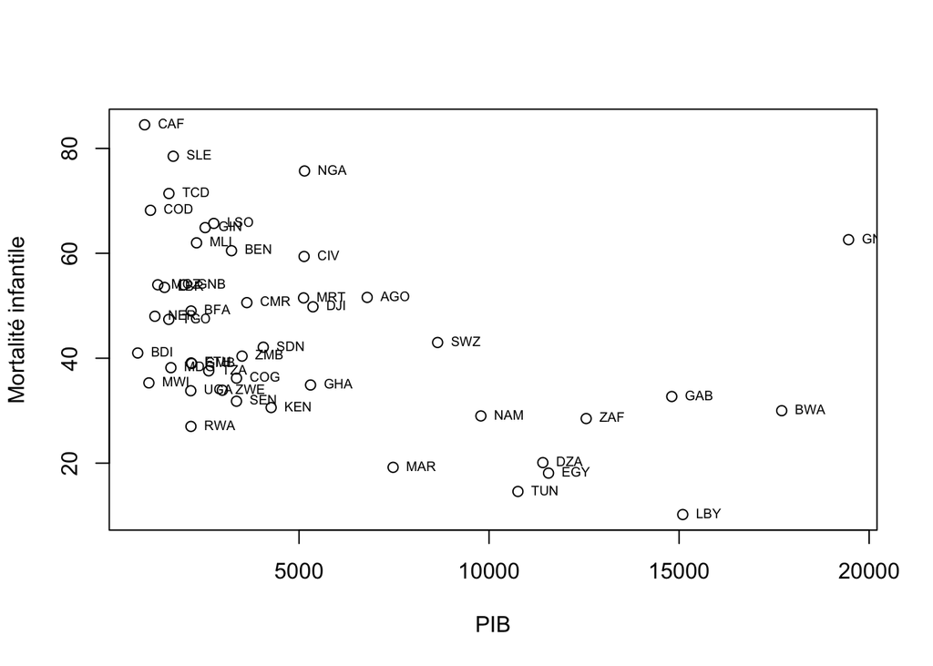

```r
plot(X,Y, xlab="PIB",ylab="Mortalité infantile")
text(X,Y,don$iso3,pos = 4,cex=0.6)
```

- Test (Pearson)

```r
cor.test(Y,X)
```

```
    Pearson's product-moment correlation

data:  Y and X
t = -3.2035, df = 44, p-value = 0.002526
alternative hypothesis: true correlation is not equal to 0
95 percent confidence interval:
 -0.6438911 -0.1654734
sample estimates:
       cor
-0.4348812
```